# Of mice and men

Here we are working on the data from Zhang *et al.* Short-course chemotherapy with TMC207 and rifapentine in a murine model of latent tuberculosis infection. *American Journal of Respiratory and Critical Care Medicine* 184.6 (2011): 732-737. [10.1164/rccm.201103-0397OC](https://doi.org/10.1164/rccm.201103-0397oc)

The data show the proportion of positive mice as a function of time (about 15 mice per time point and treatment) but we are interested in is the CFU clearance dynamics at the individual level. Since the former is a consequence of the latter, we develop a simple model of CFU clearance at the individual level from which we compute the consequences at (small-size) population level. By confronting the model-predicted consequences at population level with actual experimental data, we are able to estimate the two parameters of the model. Once the model is calibrated, we can use it to explore what would be the effect of decreasing the initial value of CFU on the time at which the individual clear the infection.

The model itself is a simple exponential decay model with inter-individual variability on the rate of decay that is modelled by a Gamma distribution.

## 1 Packages

Loading the packages needed for the analysis:

```r
library(readxl)
library(dplyr)
library(purrr)
library(tidyr)
library(bbmle)
```

## 2 Utilitary functions

A function that adds proportions estimates and confidence intervals to a data frame from a column of successes and a column or trials:

```r
add_prop_est <- function(df, x, n, p = "est", l = "lwr", u = "upr", ...) {
  df |>
    mutate(test   = map2({{ x }}, {{ n }}, prop.test, ...),
           "{p}" := map_dbl(test, ~ .x[["estimate"]]),
           conf   = map(test, ~ setNames(.x[["conf.int"]], c(l, u)))) |>
    unnest_wider(conf) |>
    select(- test)
}
```

A reparameterization of `dgamma()`:

```r
dgamma2 <- function(x, mu, sigma) {
  dgamma(x, mu^2 / sigma^2, scale = sigma^2 / mu)
}
```

A reparameterization of `qgamma()`:

```r
qgamma2 <- function(p, mu, sigma) {
  qgamma(p, mu^2 / sigma^2, scale = sigma^2 / mu)
}
```

Tuning `abline()`:

```r
abline2 <- function(...) abline(..., col = "lightgrey")
```

## 3 The data

Reading the data:

```r
table2 <- read_excel("table 2 Zhang et al 2011.xlsx")
```

The data look like this:

```r
table2
```

```
## # A tibble: 9 × 4
##   group   duration positive total
##   <chr>      <dbl>    <dbl> <dbl>
## 1 INH            4       15    15
## 2 INH            6       15    15
## 3 RIF            2       15    15
## 4 RIF            3       13    15
## 5 RIF            4        6    13
## 6 RIF+INH        2       14    15
## 7 RIF+INH        3        7    13
## 8 RPT+INH        1        9    15
## 9 RPT+INH        2        0    15
```

Preparing the data for vizualization:

- jittering the duration variable slightly in order to avoid visual overlap
- computing the proportions of positive mice with 95% confidence intervals

```r
table2a <- table2 |>
  add_prop_est(positive, total) |>
  mutate_at("duration", jitter, factor = .2)
```

It looks like this:

```r
table2a
```

```
## # A tibble: 9 × 7
##   group   duration positive total   est   lwr   upr
##   <chr>      <dbl>    <dbl> <dbl> <dbl> <dbl> <dbl>
## 1 INH         4.03       15    15 1     0.747 1
## 2 INH         5.99       15    15 1     0.747 1
## 3 RIF         2.03       15    15 1     0.747 1
## 4 RIF         2.99       13    15 0.867 0.584 0.977
## 5 RIF         3.97        6    13 0.462 0.204 0.739
## 6 RIF+INH     1.98       14    15 0.933 0.660 0.997
## 7 RIF+INH     2.98        7    13 0.538 0.261 0.796
## 8 RPT+INH     1.01        9    15 0.6   0.329 0.825
## 9 RPT+INH     1.96        0    15 0     0     0.253
```

A function that adds proportion estimates and confidence intervals to a plot:

```r
add_data <- function(x, col, connect = TRUE) {
  table2a |>
    filter(group == x) |>
    with({
      points(duration, est, col = col, type = ifelse(connect, "o", "p"))
      arrows(duration, lwr, duration, upr, .1, 90, 3, col)
      if (connect) {
        lines(duration, lwr, lty = 2, col = col)
        lines(duration, upr, lty = 2, col = col)
      }
    })
}
```

The plot showing points estimates with confidence intervals from the data:

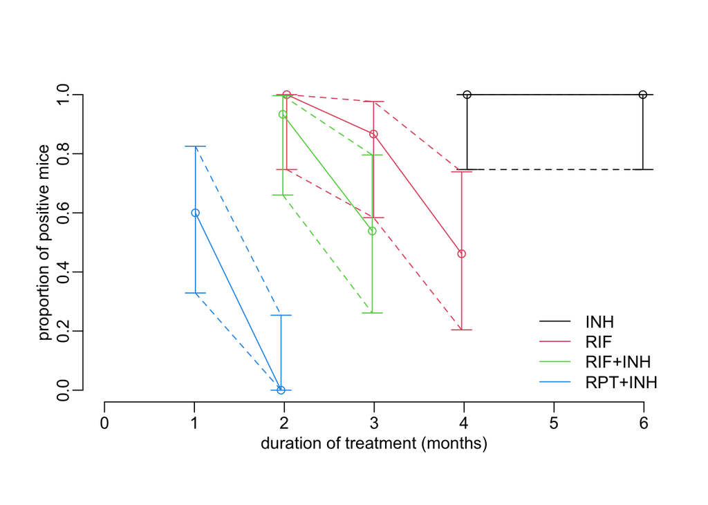

```r
treatments <- unique(table2$group)

plot(NA, xlim = c(0, 6), ylim = 0:1,
     xlab = "duration of treatment (months)",
     ylab = "proportion of positive mice")

walk2(treatments, 1:4, add_data)

legend("bottomright", legend = treatments, col = 1:4, lwd = 1, bty = "n")
```

## 4 A simple model of decay

### 4.1 Within-individual exponential decay of CFU

Let’s assume that the CFU in an individual decays at a constant rate $\lambda$. Then CFU as a function of time $t$ reads:

$$\mbox{CFU}(t) = \mbox{CFU}_0 e^{-\lambda t}$$

A function that gives CFU as a function of initial CFU$_0$, decay rate and time:

```r
cfu <- function(cfu0, lambda, t) {
  cfu0 * exp(- lambda * t)
}
```

Let’s try it:

```r
cfu(1e4, .115, 30)
```

```
## [1] 317.4564
```

```r
cfu(1e4, .115, c(30, 60))
```

```
## [1] 317.45636  10.07785
```

### 4.2 Inter-individual variability of decay rate

The next step is to consider that the rate of exponential decay varies slightly from individual to individual. Let’s consider that this inter-individual variability follows a Gamma distribution. Next, we want to work out how this inter-individual variability translates into a proportion of positive individuals in a population of an infinite number of individuals at time $t$. This is done by looking at the cumulative probability of the Gamma distribution of the decay rate that leads to the quantile of the inter-individual CFU distribution that is the closest to 1. To do so, we need a function that expresses the distance of the quantile of the inter-individual CFU distribution to 1:

```r
distance_to_1 <- function(p, lambda, sigma, N0, t) {
  abs(1 - cfu(N0, qgamma2(p, lambda, sigma), t))
}
```

We then use this function in the following function that converts values for $\lambda$ and $\sigma$ of the Gamma distribution of the inter-individual variability of exponential decay rate into the probability parameter of a binomial distribution that corresponds to the expected proportion of positive individuals in the population:

```r
probability <- function(lambda, sigma, N0, t, epsilon = 1e-16) {
  upr <- cfu(N0, qgamma2(epsilon, lambda, sigma), t)
  if (upr < 1) {
    return(0)
  } else {
    lwr <- cfu(N0, qgamma2(1 - epsilon, lambda, sigma), t)
    if (lwr > 1) {
      return(1)
    }
    else {
      optimize(distance_to_1, 0:1, lambda = lambda, sigma = sigma, N0 = N0, t = t)$minimum
    }
  }
}
```

Let’s try it:

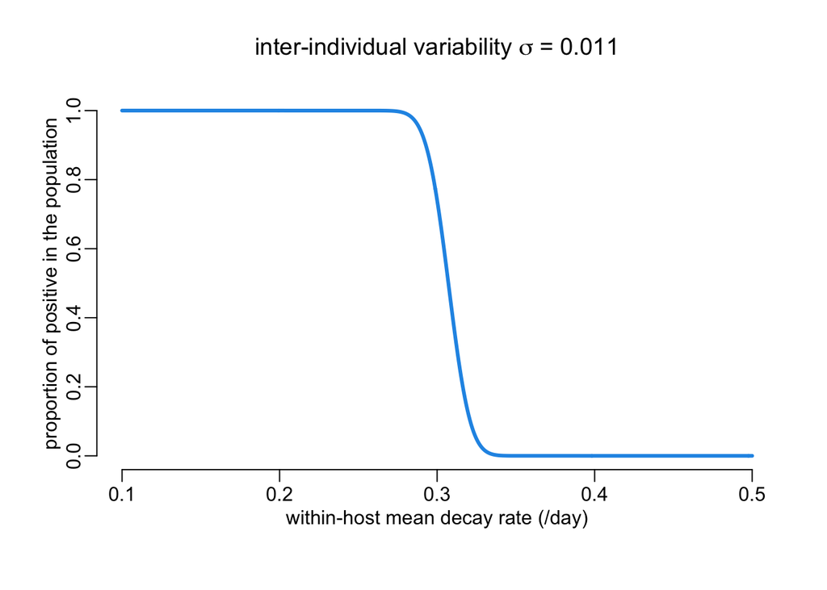

```r
xs <- seq(.1, .5, le = 512)
plot(xs, map_dbl(xs, probability, sigma = .011, N0 = 1e4, t = 30, epsilon = 1e-16),
     type = "l", col = 4, lwd = 3,
     main = expression(paste("inter-individual variability ", sigma, " = 0.011")),
     xlab = "within-host mean decay rate (/day)",
     ylab = "proportion of positive in the population")
```

## 5 Maximum-likelihood estimation of the model’s parameters

The first step consists in expressing a function that computes minus log likelihood:

```r
threshold <- - log(1e-16)

mLL <- function(lambda, sigma, N0, data, epsilon = 1e-16) {
  min(threshold,
      - sum(dbinom(data$positive,
                   data$total,
                   map_dbl(data$duration, ~ probability(lambda, sigma, N0, .x * 30, epsilon)),
                   TRUE)))
}
```

Let’s try it:

```r
mLL(lambda = .3, sigma = .011, N0 = 1e4, data = filter(table2, group == "RIF"), epsilon = 1e-16)
```

```
## [1] 36.84136
```

### 5.1 Vizualization of the likelihood surface:

Since we have only 2 parameters, we can easily have a look at the likelihood surface. A function that vizualizes the likelihood surface:

```r
show_mLL <- function(drug, lambda_val, sigma_val, N0 = 1e4, epsilon = 1e-16, ...) {
  values <- expand.grid(lambda_val, sigma_val)

  mLL_val <- map2_dbl(values$Var1, values$Var2, mLL, N0 = N0,
                      data = filter(table2, group == drug), epsilon = epsilon) |>
    matrix(length(lambda_val))

  image(lambda_val, sigma_val, mLL_val, xlab = "lambda", ylab = "sigma")
  contour(lambda_val, sigma_val, mLL_val, add = TRUE, ...)
  box(bty = "o")
}
```

Let’s try it:

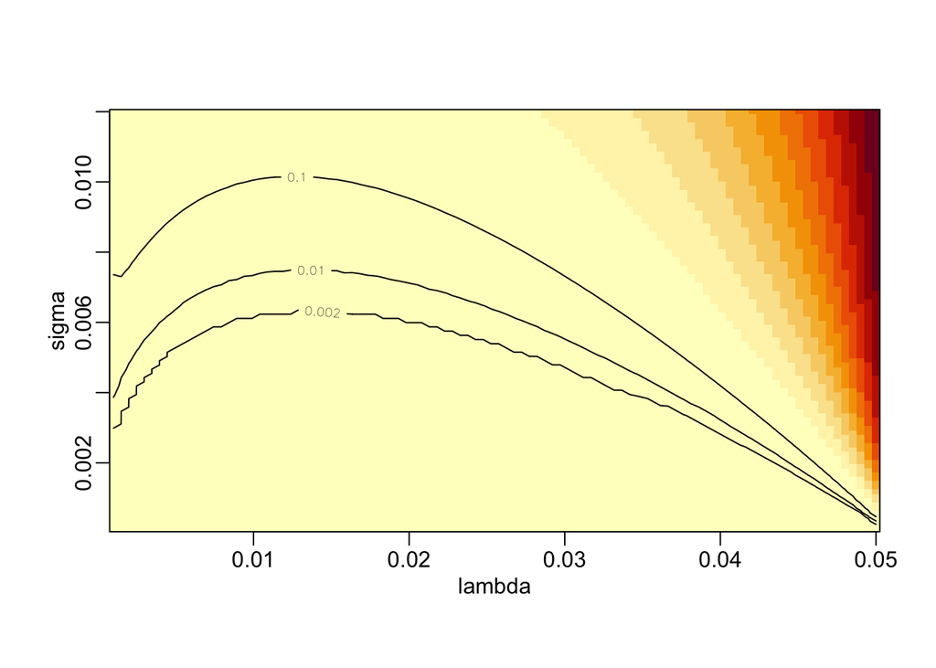

```r
show_mLL("INH", seq(.001, .05, le = 100), seq(.0001, .012, le = 100), levels = c(.002, .01, .1))
```

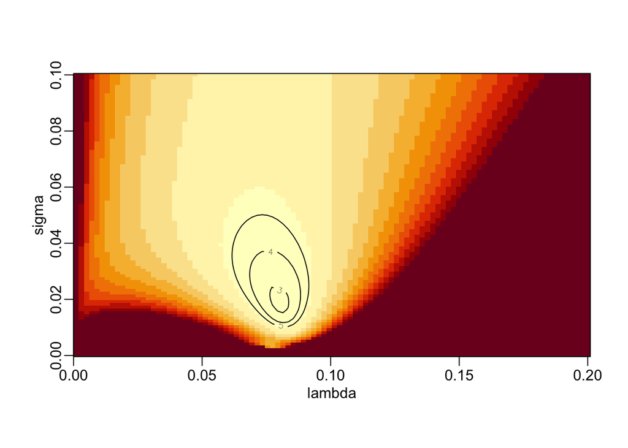

```r
show_mLL("RIF", seq(.001, .2, le = 100), seq(.0001, .1, le = 100), levels = 1:5)
```

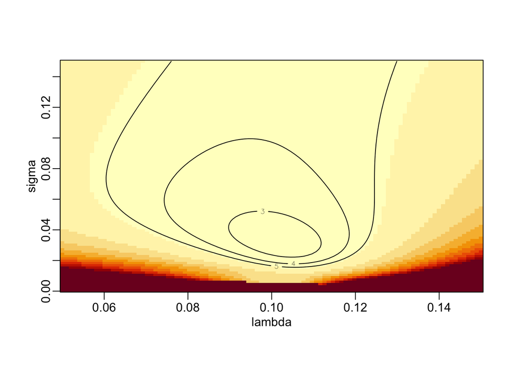

```r
show_mLL("RIF+INH", seq(.05, .15, le = 100), seq(.0001, .15, le = 100), levels = 1:5)
```

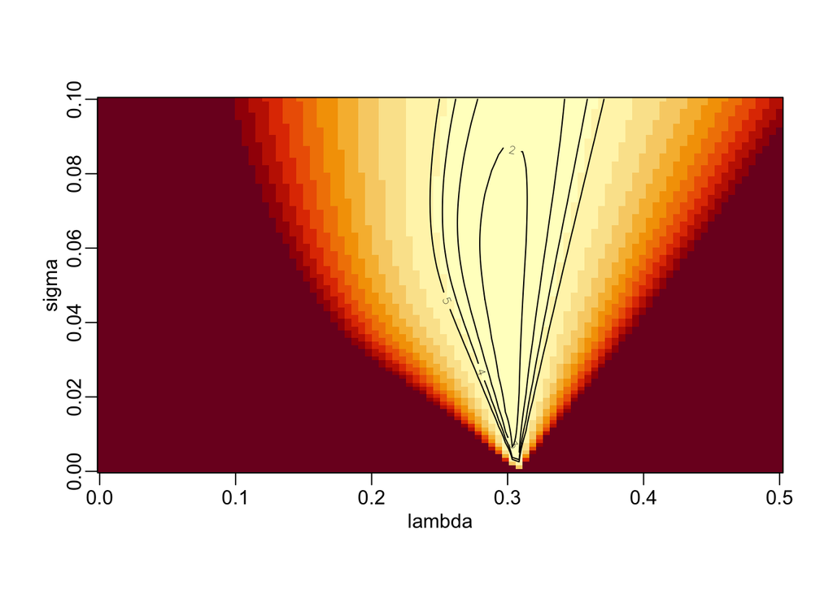

```r
show_mLL("RPT+INH", seq(.001, .5, le = 100), seq(.0001, .1, le = 100), levels = 1:5)
```

### 5.2 MLE using the BFGS quasi-Newton algorithm

A function that performs estimations:

```r
estimations <- function(lambda, sigma, lower, upper, drug, N0 = 1e4, epsilon = 1e-16) {
  data <- filter(table2, group == drug)
  mle2(function(lambda, sigma) mLL(lambda, sigma, N0, data, epsilon),
       list(lambda = lambda, sigma = sigma), "L-BFGS-B",
       lower = lower, upper = upper)
}
```

Let’s use it:

```r
est_RIF <- estimations(lambda = .08, sigma = .02,
                       lower = c(lambda = .06, sigma = .01),
                       upper = c(lambda = .09, sigma = .05),
                       drug = "RIF")

est_RIFINH <- estimations(lambda = .11, sigma = .04,
                          lower = c(lambda = .09, sigma = .02),
                          upper = c(lambda = .11, sigma = .05),
                          drug = "RIF+INH")

est_RPTINH <- estimations(lambda = .3, sigma = .04,
                          lower = c(lambda = .28, sigma = .01),
                          upper = c(lambda = .32, sigma = .08),
                          drug = "RPT+INH")
```

Which gives:

```r
coef(est_RIF)
```

```
##     lambda      sigma
## 0.08023574 0.01919793
```

```r
coef(est_RIFINH)
```

```
##     lambda      sigma
## 0.10253813 0.03165679
```

```r
coef(est_RPTINH)
```

```
##     lambda      sigma
## 0.29886882 0.03829734
```

### 5.3 Vizualizaiton of model predictions

The following figure shows the estimated inter-individual variability of the exponential decay rate:

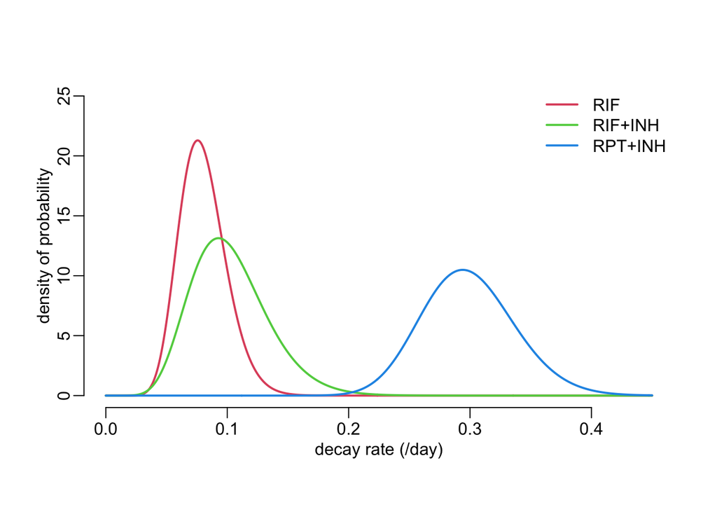

```r
x_max <- .45

x_val <- seq(0, x_max, le = 512)
add_lines <- function(x, col) {
  lines(x_val, dgamma2(x_val, x["lambda"], x["sigma"]), lwd = 2, col = col)
}

plot(NA, xlim = c(0, x_max), ylim = c(0, 25),
     xlab = "decay rate (/day)", ylab = "density of probability")

add_lines(coef(est_RIF), 2)
add_lines(coef(est_RIFINH), 3)
add_lines(coef(est_RPTINH), 4)

legend("topright", legend = treatments[-1], col = 2:4, lwd = 2, bty = "n")
```

A function that adds model predictions to a plot:

```r
add_pred <- function(x, col, t_max, cfu0 = 1e4, alpha = .2, aggregation = 7) {
  t_val <- seq(0, t_max, le = 512)
  q050 <- cfu(cfu0, qgamma2(.500, x["lambda"], x["sigma"]), t_val)
  q025 <- cfu(cfu0, qgamma2(.025, x["lambda"], x["sigma"]), t_val)
  q975 <- cfu(cfu0, qgamma2(.975, x["lambda"], x["sigma"]), t_val)
  t_val <- t_val / aggregation
  polygon(c(t_val, rev(t_val)), c(q025, rev(q975)), border = NA,
          col = adjustcolor(col, alpha))
  lines(t_val, q050, col = col, lwd = 2)
}
```

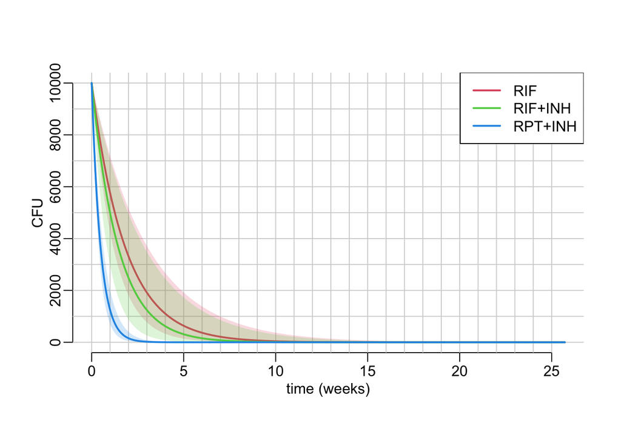

```r
t_max <- 6 * 30 # in days

plot(NA, xlim = c(0, t_max / 7), ylim = c(0, 1e4), xlab = "time (weeks)", ylab = "CFU")

abline2(v = 0:25)
abline2(h = 0:10 * 1e3)

add_pred(coef(est_RIF),    2, t_max)
add_pred(coef(est_RIFINH), 3, t_max)
add_pred(coef(est_RPTINH), 4, t_max)

legend("topright", legend = treatments[-1], col = 2:4, lwd = 2)
```

The same plot over a month:

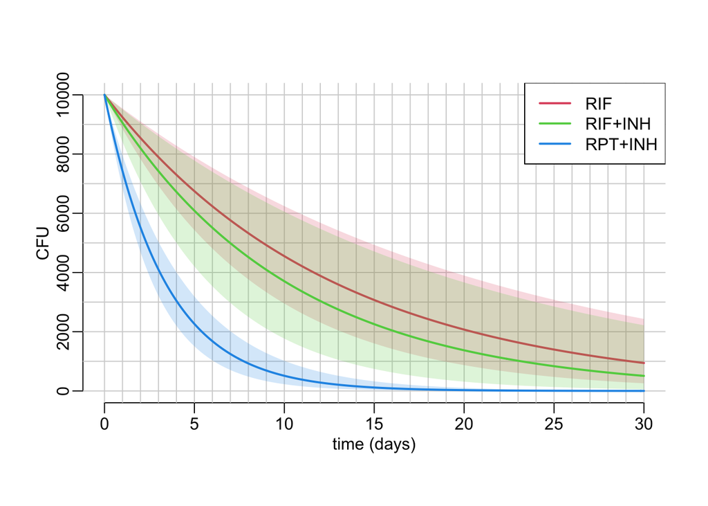

```r
t_max <- 30 # in days

plot(NA, xlim = c(0, t_max), ylim = c(0, 1e4), xlab = "time (days)", ylab = "CFU")

abline2(v = 0:30)
abline2(h = 0:10 * 1e3)

add_pred(coef(est_RIF),    2, t_max, aggregation = 1)
add_pred(coef(est_RIFINH), 3, t_max, aggregation = 1)
add_pred(coef(est_RPTINH), 4, t_max, aggregation = 1)

legend("topright", legend = treatments[-1], col = 2:4, lwd = 2)
```

Same figure on a log scale:

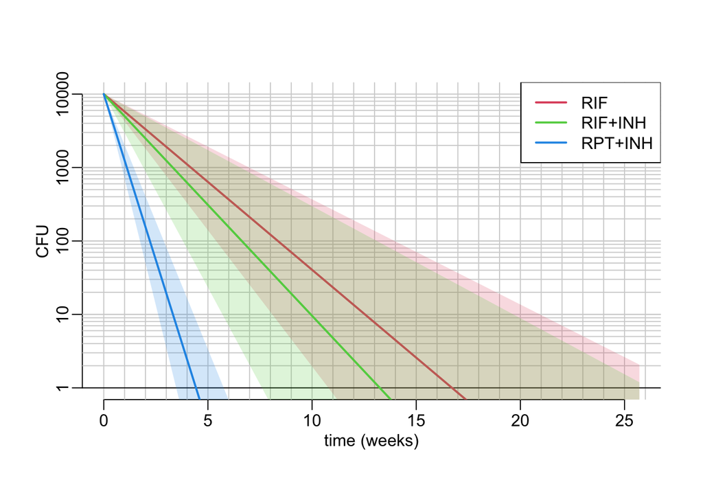

```r
t_max <- 6 * 30 # in days

plot(NA, xlim = c(0, t_max / 7), ylim = c(1, 1e4), xlab = "time (weeks)", ylab = "CFU", log = "y")

abline2(h = 1:10 * 1e3)
abline2(h = 1:10 * 1e2)
abline2(h = 1:10 * 10)
abline2(h = 2:10)
abline2(v = 0:30)
abline(h = 1)

add_pred(coef(est_RIF),    2, t_max)
add_pred(coef(est_RIFINH), 3, t_max)
add_pred(coef(est_RPTINH), 4, t_max)

legend("topright", legend = treatments[-1], col = 2:4, lwd = 2)
```

A function that adds model-predicted proportions of individual with CFU > 1 in a population of 15 individuals:

```r
add_mod_pred <- function(x, col, alpha = .2) {
  t_val <- seq(0, 6 * 30, le = 512)
  p_val <- map_dbl(t_val, ~ probability(x["lambda"], x["sigma"], N0 = 1e4, t = .x, epsilon = 1e-16))
  t_val <- t_val / 30
  q025 <- qbinom(.025, 15, p_val) / 15
  q975 <- qbinom(.975, 15, p_val) / 15
  polygon(c(t_val, rev(t_val)), c(q025, rev(q975)), border = NA, col = adjustcolor(col, alpha))
  lines(t_val, qbinom(.5, 15, p_val) / 15, col = col)
}
```

Proportion of individuals with CFU > 1 as a function of time in a population of 15 individuals:

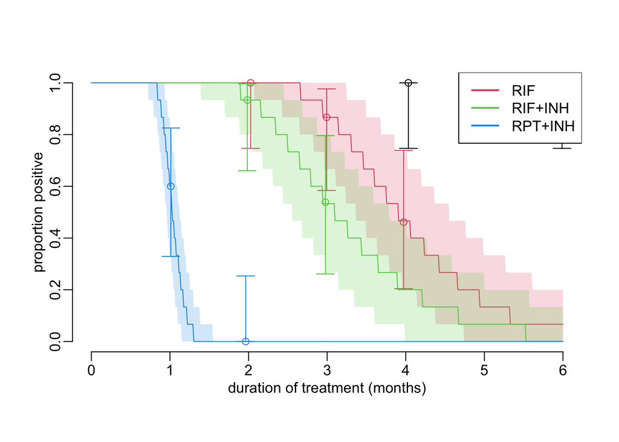

```r
plot(NA, xlim = c(0, 6), ylim = 0:1,
     xlab = "duration of treatment (months)",
     ylab = "proportion positive")

walk2(treatments, 1:4, add_data, connect = FALSE)

add_mod_pred(coef(est_RIF), 2)
add_mod_pred(coef(est_RIFINH), 3)
add_mod_pred(coef(est_RPTINH), 4)


legend("topright", legend = treatments[-1], col = 2:4, lwd = 2)
```

## 6 Speculating on effects in humans

```r
add_pred2 <- function(x, cfu0 = 1e4, col, t_max, alpha = .2, f = I) {
  t_val <- seq(0, t_max, le = 512)
  q050 <- f(cfu(cfu0, qgamma2(.500, x["lambda"], x["sigma"]), t_val))
  q025 <- f(cfu(cfu0, qgamma2(.025, x["lambda"], x["sigma"]), t_val))
  q975 <- f(cfu(cfu0, qgamma2(.975, x["lambda"], x["sigma"]), t_val))
  polygon(c(t_val, rev(t_val)), c(q025, rev(q975)), border = NA, col = adjustcolor(col, alpha))
  lines(t_val, q050, col = col, lwd = 2)
}
```

```r
CFU0_effect <- function(cfu0) {
  t_max <- 6 * 30

  plot(NA, xlim = c(0, t_max / 7), ylim = c(1, 1e4), xlab = "time (weeks)", ylab = "CFU", log = "y")

  abline2(h = 1:10 * 1e3)
  abline2(h = 1:10 * 1e2)
  abline2(h = 1:10 * 10)
  abline2(h = 2:10)
  abline2(v = 0:30)
  abline(h = 1)

  add_pred(coef(est_RIF),    2, t_max, cfu0)
  add_pred(coef(est_RIFINH), 3, t_max, cfu0)
  add_pred(coef(est_RPTINH), 4, t_max, cfu0)

  legend("topright", legend = treatments[-1], col = 2:4, lwd = 2)
}
```

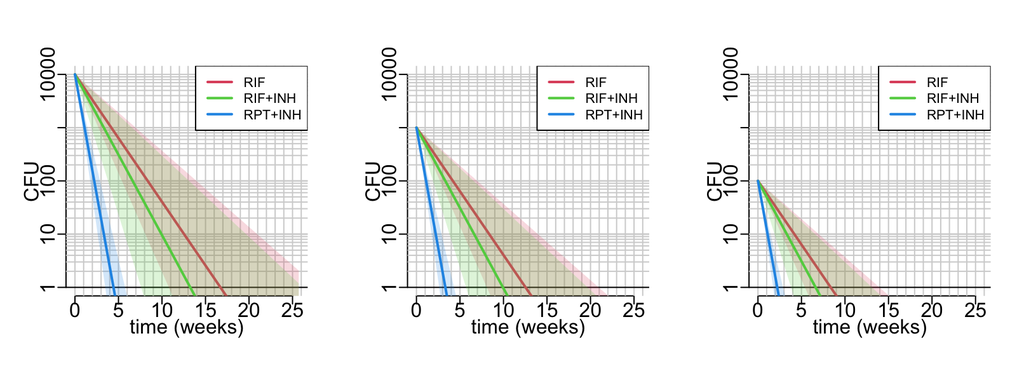

```r
opar <- par(mfrow = c(1, 3), cex.axis = 1.5, cex.lab = 1.5)
CFU0_effect(1e4)
CFU0_effect(1e3)
CFU0_effect(1e2)
```

```r
par(opar)
```

```r
cfu1_time <- function(x, cfu0 = 1e4, p = .5) {
  optimize(function(t) abs(log(cfu(cfu0, qgamma2(p, x["lambda"], x["sigma"]), t))), c(0, 200))$minimum
}
```

Let’s try it:

```r
cfu1_time(coef(est_RIF), cfu0 = 1e4, p = .5)
```

```
## [1] 117.0163
```

```r
cfu1_time(coef(est_RIF), cfu0 = 1e4, p = .025)
```

```
## [1] 195.4337
```

```r
cfu1_time(coef(est_RIF), cfu0 = 1e4, p = .975)
```

```
## [1] 75.48924
```

```r
CFU0_effect_cfu1_time <- function(x, cfu0 = 1e4) {
  cfu1_time(coef(est_RIF), cfu0 = 1e4, p = .5)
  cfu1_time(coef(est_RIF), cfu0 = 1e4, p = .025)
  cfu1_time(coef(est_RIF), cfu0 = 1e4, p = .975)
}
```

```r
f <- function(x, cfu0) {
  map_dfc(c(upper = .025, median = .5, lower = .975), cfu1_time, x = x, cfu0 = cfu0)
}
```

Let’s try it:

```r
f(coef(est_RIF), 1e4)
```

```
## # A tibble: 1 × 3
##   upper median lower
##   <dbl>  <dbl> <dbl>
## 1  195.   117.  75.5
```

```r
cfu0_val <- seq(1e2, 1e4, le = 512)
out <- map_dfr(cfu0_val, f, x = coef(est_RIF))
```

```r
add_speculation1 <- function(x, col, alpha = .2) {
  cfu0_val <- 10^seq(2, 4, le = 512)
  out <- map_dfr(cfu0_val, f, x = coef(x))
  polygon(c(cfu0_val, rev(cfu0_val)), c(out$upper, rev(out$lower)),
          border = NA, col = adjustcolor(col, .2))
  lines(cfu0_val, out$median, col = col, lwd = 3)
}
```

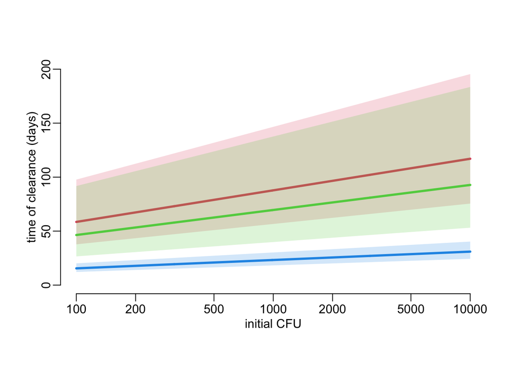

```r
plot(NA, xlim = 10^c(2, 4), ylim = c(0, 200), log = "x",
     xlab = "initial CFU", ylab = "time of clearance (days)")
add_speculation1(est_RIF, 2)
add_speculation1(est_RIFINH, 3)
add_speculation1(est_RPTINH, 4)
```